{% raw %}

{% endraw %} {% raw %}

{% endraw %} {% raw %}

`class` `Schedule`[[source]](https://github.com/nathanhubens/fasterai/tree/master/fasterai/sparse/schedule.py#L14)

> `Schedule`(**`sched_func`**, **`start_pct`**=*`0.0`*, **`end_pct`**=*`None`*, **`start_sparsity`**=*`0.0`*)

{% endraw %} {% raw %}

{% endraw %}

## One-Shot

The easiest schedule is the one-shot pruning, i.e. prune the network once. This can be done by simply returning the desired sparsity value. The moment when you want to prune will be controlled by the `start_epoch` argument in the `SparsifyCallback`.

{% raw %}

`sched_oneshot`[[source]](https://github.com/nathanhubens/fasterai/tree/master/fasterai/sparse/schedule.py#L46)

> `sched_oneshot`(**`start`**, **`end`**, **`pos`**)

{% endraw %} {% raw %}

{% endraw %} {% raw %}

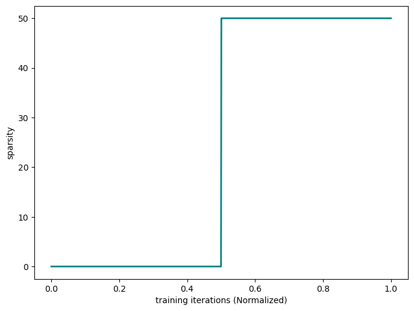

```python
one_shot.plot(50)
```

{% endraw %}

## Iterative

Instead of pruning the network to desired sparsity in one step, you can do it iteratively. In fasterai, you can change the amount of iterations

{% raw %}

`sched_iterative`[[source]](https://github.com/nathanhubens/fasterai/tree/master/fasterai/sparse/schedule.py#L51)

> `sched_iterative`(**`start`**, **`end`**, **`pos`**, **`n_steps`**=*`3`*)

Perform iterative pruning, and pruning in `n_steps` steps

{% endraw %} {% raw %}

{% endraw %} {% raw %}

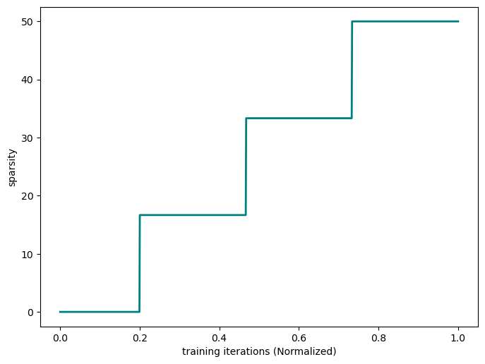

```python
iterative.plot(50)
```

{% endraw %}

To modify the default `n_steps`, you can use the `partial` function.

{% raw %}

```python
iterative = Schedule(partial(sched_iterative, n_steps=5), start_pct=0.2)
```

{% endraw %} {% raw %}

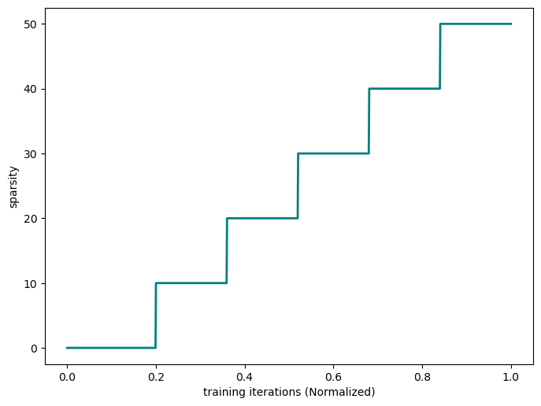

```python
iterative.plot(50)
```

{% endraw %}

## Automated Gradual Pruning

Some researchers have come up with more sophisticated schedules, such as the [Automated Gradual Pruning](https://arxiv.org/abs/1710.01878).

{% raw %}

`sched_agp`[[source]](https://github.com/nathanhubens/fasterai/tree/master/fasterai/sparse/schedule.py#L58)

> `sched_agp`(**`start`**, **`end`**, **`pos`**)

{% endraw %} {% raw %}

{% endraw %} {% raw %}

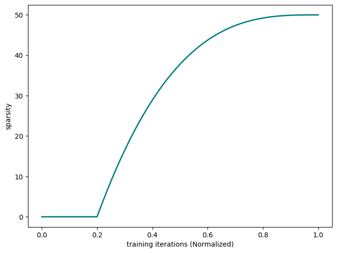

```python
agp.plot(50)
```

{% endraw %}

## One-Cycle Pruning

{% raw %}

`sched_onecycle`[[source]](https://github.com/nathanhubens/fasterai/tree/master/fasterai/sparse/schedule.py#L63)

> `sched_onecycle`(**`start`**, **`end`**, **`pos`**, **`α`**=*`14`*, **`β`**=*`6`*)

{% endraw %} {% raw %}

{% endraw %} {% raw %}

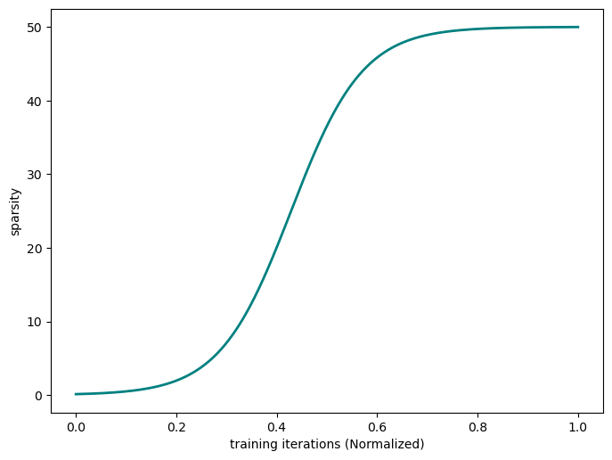

```python
one_cycle.plot(50)
```

{% endraw %}

On top of that, all of the schedules available in fastai by default are also available:

- sched_cos
- sched_linear

{% raw %}

{% endraw %}

## Dense-Sparse-Dense

You can also create even more interesting behaviours such as the DSD method, where you prune the model in the first place, then re-grow it to its initial amount of parameter.

{% raw %}

`sched_dsd`[[source]](https://github.com/nathanhubens/fasterai/tree/master/fasterai/sparse/schedule.py#L74)

> `sched_dsd`(**`start`**, **`end`**, **`pos`**)

{% endraw %} {% raw %}

{% endraw %} {% raw %}

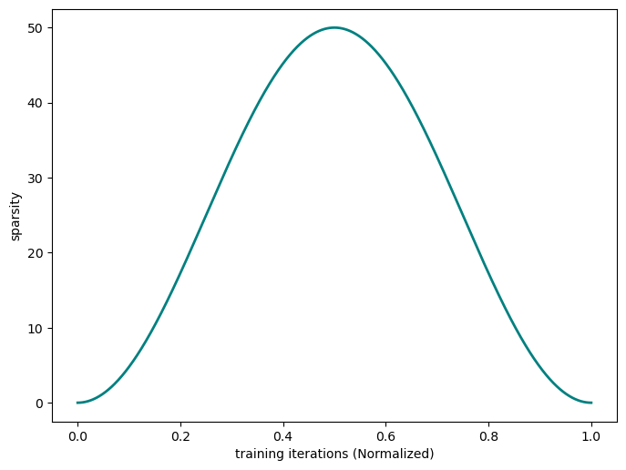

```python
dsd.plot(50)
```

{% endraw %} {% raw %}

`available_schedules`[[source]](https://github.com/nathanhubens/fasterai/tree/master/fasterai/sparse/schedule.py#L84)

> `available_schedules`()

{% endraw %} {% raw %}

{% endraw %}